# HW3 - Forecasting

### Exercise 5.4

#### Repeat the previous exercise using the Australian Exports series from global_economy. Use whichever of NAIVE() or SNAIVE() is more appropriate.

Fist I look at a plot of the data. I see an upward trend, but not any seasonality which makes sense as this is annual data. This means a naive method of forecasting is likely best.

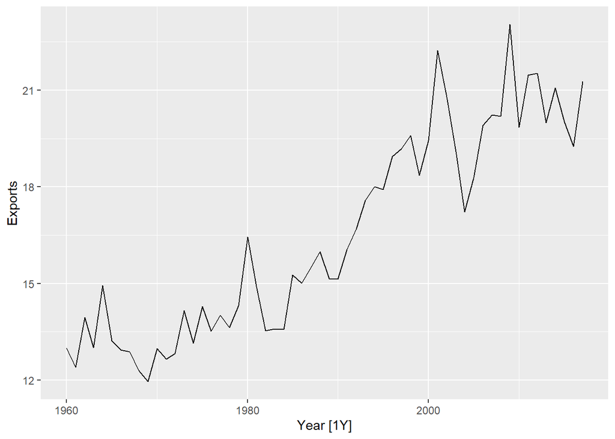

```r
# Extract data of interest
global_economy %>%
  filter(Code == "AUS") %>%
  autoplot(Exports)
```

After building the model and forecasting we look at the residual plots. On the ACF plot the only residual out of the blue bounds is 1, which I belive we can interpret as unimportant as a lag of 1 here simply means the previous year helps predict the next year. The histogram looks very symmetrical and is centered around zero. I would conclude this model has residuals that are indistinguishable from white noise, but we’ll check next.

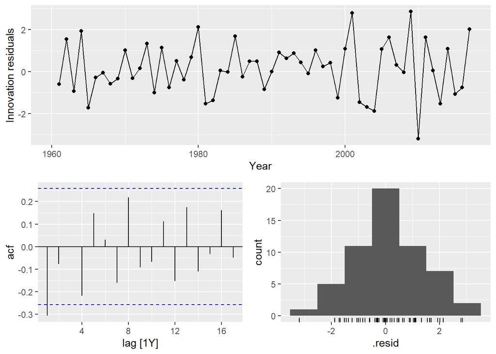

```r
# Extract data of interest
aus_exports <- global_economy %>%
  filter(Code == "AUS")
# Define and estimate a model
fit <- aus_exports %>%
  model(NAIVE(Exports))
#save residuals
resid <- aus_exports %>%
  model(NAIVE(Exports)) %>%
  augment()
# Look at the residuals
fit %>% gg_tsresiduals()
```

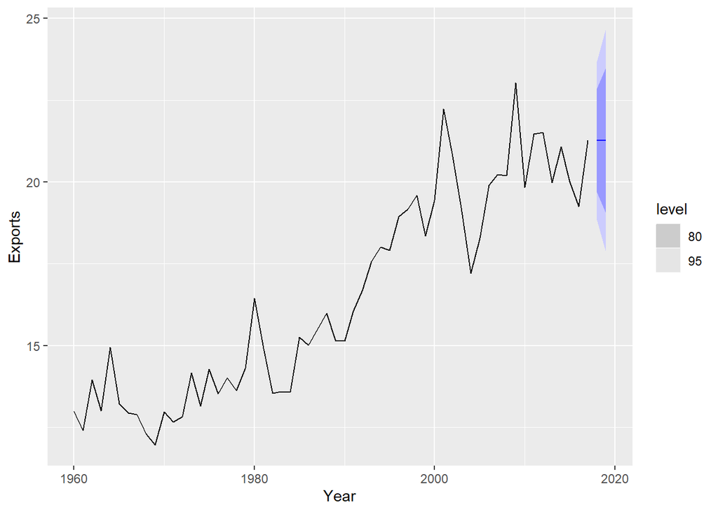

```r
# Look a some forecasts
fit %>% forecast() %>% autoplot(aus_exports)
```

To perform the Box-Pierce Test on what appears to be non-seasonal data, the textbook suggests using a lag of 10. Below we see a non-significant p-value, which confirms the conclusion above that the residuals are indistinguishable from white noise.

```r
#take residuals and use features to perform a box_pierce test
resid %>%
  features(.innov, box_pierce, lag=10, dof=0)
```

```
## # A tibble: 1 x 4
##   Country   .model         bp_stat bp_pvalue
##   <fct>     <chr>            <dbl>     <dbl>
## 1 Australia NAIVE(Exports)    14.6     0.148
```